# 3.1 Statistical analysis of chemical genomics data

gDR team

2026-11-24

3.1. Statistical analysis of chemical genomics data

**gDR Analysis Pipeline**

Date: 2026-11-24

Author: [gDR team](https://github.com/gdrplatform)

# 1 Introduction

This report performs a statistical analysis on the chemical genomics data to identify drug classes (e.g., grouped by Mechanism of Action, MOA) that show a differential response between experimental conditions. The analysis uses Gene Set Enrichment Analysis (GSEA), a method for determining whether a defined set of genes—or in this case, a set of drugs—shows statistically significant, concordant differences between two biological states.

*This example shows relative viability (RV) only. GR values need the doubling time of each cell line, which is not known for the resistant lines, so they are left out of the whole example.*

```r
library(qs2)
library(data.table)
library(writexl)
library(gDRutils)
library(gDRplots)
```

# 2 Key Output Files

This report generates the **`tables`** folder, which contains Excel files detailing the GSEA results.

### 2.0.1 GSEA Results (in `tables/` folder):

- **`cgs_tables_RV_...xlsx`:** These files contain the full GSEA results for each analysis. Each sheet in the Excel file corresponds to a specific cell line (or cell line comparison) and metric.
- **Key columns:**
- `pathway`: The drug MOA being tested.
- `padj`: The adjusted p-value (FDR) for the enrichment.
- `NES`: The Normalized Enrichment Score. A positive score indicates enrichment at the top of the ranked list (e.g., sensitization), while a negative score indicates enrichment at the bottom (e.g., rescue).
- `leadingEdge`: A comma-separated list of the drugs within the `pathway` that contribute most to the enrichment score.

# 3 Read the gDR MAE data

This section loads the final `MultiAssayExperiment` (MAE) object, which contains all the processed data and results from the previous step.

```r
wd <- getwd()
mae <- qs_read(file.path(wd, "gDR_data", "gDR_mae.qs2"))
```

# 4 Preparing assay data

The relevant data assays are extracted from the MAE object to prepare for the GSEA analysis.

```r
combo_name <- get_supported_experiments("combo")
response_metrics_combo <-
  convert_se_assay_to_dt(mae[[combo_name]], "Metrics", unify_metadata = TRUE, merge_additional_variables = TRUE)
response_data_combo <-
  convert_se_assay_to_dt(mae[[combo_name]], "Averaged", unify_metadata = TRUE, merge_additional_variables = TRUE)

response_metrics_combo_capped <-
  cap_assay_infinities(conc_assay_dt = response_data_combo,
                       assay_dt = response_metrics_combo,
                       experiment_name = combo_name,
                       col = "xc50",
                       capping_fold = 5)
```

# 5 GSEA: Comparing Co-treatment vs. Single-Agent Response

This first analysis aims to identify drug classes (MOAs) that are significantly sensitized or rescued by the co-treatment. For each cell line, it ranks all drugs based on the difference in their response as single agents versus their response in the combination. GSEA is then performed on this ranked list to see if any drug MOA is enriched at the top (sensitized) or bottom (rescued) of the list.

The tables show the GSEA results for each cell line, with each row representing a drug MOA.

**What to look for:**

- **padj (Adjusted p-value):** This is the most important column for significance. A low value (e.g., < 0.05) indicates that the enrichment of the drug set is statistically significant.
- **NES (Normalized Enrichment Score):** This indicates the direction of the effect. A **positive NES** means the drug class is enriched among drugs that were **sensitized** by the co-treatment. A **negative NES** means the drug class is enriched among drugs that were **rescued** by the co-treatment.
- **leadingEdge:** This lists the specific drugs within the MOA that contributed most to the enrichment score.

```r
# Run GSEA
analyzed_metrics <- c("x_mean", "x_AOC_range", "xc50", "ec50", "x_max")
cgs_analysis_RV <- analyze_cgs(response_metrics_combo_capped,
                               metrics = analyzed_metrics,
                               normalization_type = "RV")
```

## 5.1 Relative Viability

### 5.1.1 NCI-H23

💾 Download Table

#### 5.1.1.1 x_mean

|  | pathway | pval | padj | log2err | ES | NES | size | leadingEdge | median |
| --- | --- | --- | --- | --- | --- | --- | --- | --- | --- |
| 1 | CHEK1 | 0.00817930741448906 | 0.2641288003814134 | 0.1648824935410071 | 0.6753192281512594 | 1.775426144928896 | 7 | G10122, G10531, G10271, G10438, G10530, G10739 | 0.02129367557082784 |
| 2 | PIK3C3 | 0.04910220994475138 | 0.3829972375690608 | 0.05393170264288337 | 0.6507177033492824 | 1.474904019385763 | 5 | G10568, G10465, G10661, G10614, G10393 | -0.005916941606469384 |
| 3 | TOP2A | 0.07640565712314591 | 0.4256886611146701 | 0.04826683700672701 | 0.5673076923076923 | 1.395851572862719 | 6 | G10300, G10055, G10235, G10139, G10127, G10471 | -0.01714520326900307 |
| 4 | HDAC1\|HDAC2 | 0.1142978542596133 | 0.4952907017916577 | 0.04375435231950205 | 0.4990366140838838 | 1.311976047752738 | 7 | G10698, G10416, G10712, G10110 | 0.04717596827059278 |
| 5 | NAMPT | 0.4018983869197849 | 0.7837018544935805 | 0.01622811593319321 | 0.4952380952380953 | 1.021010685955033 | 4 | G10503, G10019, G10542, G10610 | -0.03782875374730937 |
| 6 | BRAF | 0.5148140019752002 | 0.8365727532097004 | 0.01417820994261305 | 0.4619047619047619 | 0.9522888128619057 | 4 | G10389, G10213, G10239, G10717 | -0.00488742858007668 |
| 7 | TUBB | 0.6030269588522781 | 0.8739816313806851 | 0.02287807474891281 | 0.3073170731707318 | 0.9045696982615935 | 9 | G10603, G10373, G10641, G10658, G10586, G10652, G10105, G10687, G10429 | -0.01270385313441091 |
| 8 | DNA | 0.9910032715376227 | 0.9910032715376227 | 0.0006273782460619418 | -0.2230411516615358 | -0.5115821265410736 | 20 | G10234, G10691, G10044, G10023, G10368, G10330, G10219, G10431, G10037, G10185, G10406 | -0.04869477321079096 |
| 9 | HSP90AA1\|HSP90AB1 | 0.9821636600124414 | 0.9910032715376227 | 0.001776221971623882 | -0.2973902253336238 | -0.5593967942755123 | 6 | G10506, G10522, G10589, G10092 | -0.02707790077959957 |
| 10 | 20S proteasome | 0.9487292331389592 | 0.9910032715376227 | 0.002450700511387038 | -0.3768529942716721 | -0.6477788317393242 | 4 | G10339 | -0.01115570386873513 |

[output cut: 29 more lines]

#### 5.1.1.2 x_AOC_range

|  | pathway | pval | padj | log2err | ES | NES | size | leadingEdge | median |
| --- | --- | --- | --- | --- | --- | --- | --- | --- | --- |
| 1 | NR3C1 | 0.0368824174953897 | 0.4024741927188568 | 0.02485439779442762 | 0.7548820367396439 | 1.420634874577833 | 6 | G10594 | 0.0001499999999999835 |
| 2 | PIK3CA | 0.04127940438142121 | 0.4024741927188568 | 0.02442768300670247 | 0.819047619047619 | 1.407968829365841 | 4 | G10595, G10557, G10253, G10612 | 0.169652930573352 |
| 3 | BRD9 | 0.08843662368514504 | 0.5391358944130701 | 0.01635251622384009 | 0.7676130466566418 | 1.319551168421458 | 4 | G10087, G10144 | 0.06046693688199406 |
| 4 | TEAD1\|TEAD2\|TEAD3\|TEAD4 | 0.08984485017694673 | 0.5391358944130701 | 0.01621378887347592 | 0.7666666666666666 | 1.317924311208723 | 4 | G10544, G10686, G10277, G10057 | 0.2042400263877612 |
| 5 | MDM2 | 0.113966637073034 | 0.5391358944130701 | 0.01387587123460525 | 0.7124327604449425 | 1.287582250813384 | 5 | G10550, G10026, G10290, G10159 | 0.1511807939249885 |
| 6 | CREBBP | 0.1423952433652323 | 0.5391358944130701 | 0.0117381869779241 | 0.6253759687005103 | 1.249430613285978 | 8 | G10491, G10715, G10114, G10700 | 0.07956811390239754 |
| 7 | KDM2B | 0.1520639702190711 | 0.5391358944130701 | 0.01211619564109836 | 0.7238095238095238 | 1.244251523625627 | 4 | G10651, G10214, G10447, G10209 | 0.1612120108448682 |
| 8 | MTOR | 0.1708729779704395 | 0.5553371784039284 | 0.01132921298512803 | 0.7126269642335292 | 1.225028349112484 | 4 | G10308, G10131, G10208 | 0.1581939885402293 |
| 9 | HMGCR | 0.1977508513502811 | 0.5624780237946543 | 0.009913026021705306 | 0.6370026573874437 | 1.198794177421221 | 6 | G10432, G10257, G10577 | 0.0947145417280118 |
| 10 | ERN1 | 0.2019151880288503 | 0.5624780237946543 | 0.0102673252794394 | 0.696404829138711 | 1.197141984476171 | 4 | G10369, G10284 | 0.1086112691475424 |

[output cut: 29 more lines]

#### 5.1.1.3 xc50

|  | pathway | pval | padj | log2err | ES | NES | size | leadingEdge | median |
| --- | --- | --- | --- | --- | --- | --- | --- | --- | --- |
| 1 | NR3C1 | 0.003613500036135 | 0.140926501409265 | 0.1445589553132464 | 0.9711538461538461 | 1.651674251868153 | 6 | G10740 | 0 |
| 2 | HDAC1\|HDAC2 | 0.08916669804571299 | 0.4346876529728508 | 0.02929724434509403 | 0.822733575367274 | 1.46227096219355 | 7 | G10698, G10416, G10712, G10110 | 0.1518833538175803 |
| 3 | PPARG | 0.07002997002997002 | 0.3901669758812615 | 0.03113094875506622 | 0.926388347559704 | 1.408199960474238 | 4 | G10657 | 0 |
| 4 | MAPK14 | 0.1508491508491508 | 0.5555650831761276 | 0.02094517802739466 | 0.8809523809523809 | 1.339132893137861 | 4 | G10413 | 0 |
| 5 | CHEK1 | 0.177015476145649 | 0.5555650831761276 | 0.02054224356125226 | 0.7404571722984619 | 1.316038453051634 | 7 | G10122, G10531, G10438, G10271, G10530, G10739 | 0.08607474966828432 |
| 6 | KRAS | 0.2726547044736751 | 0.6176725783500503 | 0.01562508626069583 | 0.7684972008235301 | 1.241448136390187 | 5 | G10296 | -0.02808530503799811 |
| 7 | MDM2 | 0.2850796515461771 | 0.6176725783500503 | 0.01525105579493737 | 0.7584790019668217 | 1.225264506459825 | 5 | G10550 | -0.04018458083794496 |
| 8 | PARP1\|PARP2 | 0.3794538794538794 | 0.696702798363013 | 0.01272205832733007 | 0.7573140284416316 | 1.151190629423759 | 4 | G10295 | 0.02403202108827537 |
| 9 | BRAF | 0.3824841824841825 | 0.696702798363013 | 0.01266505082150528 | 0.7543424263991334 | 1.146673506675168 | 4 | G10239 | -0.03248013089210067 |
| 10 | DNA | 0.401178167828805 | 0.696702798363013 | 0.0170608346225894 | 0.4266795918547331 | 1.018743290377811 | 20 | G10455, G10501, G10441, G10037, G10734, G10070 | 0 |

[output cut: 29 more lines]

#### 5.1.1.4 ec50

|  | pathway | pval | padj | log2err | ES | NES | size | leadingEdge | median |
| --- | --- | --- | --- | --- | --- | --- | --- | --- | --- |
| 1 | KRAS | 0.03717973888288996 | 0.4833366054775695 | 0.03678968385860081 | 0.9871392871826689 | 1.255380545548583 | 5 | G10296 | -0.01180714544846659 |
| 2 | SMARCA4 | 0.1274179148893959 | 0.9212946561423894 | 0.01960405726756184 | 0.9666666666666667 | 1.218514085696191 | 4 | G10140 | 0 |
| 3 | ESR1 | 0.2613148331681533 | 0.9212946561423894 | 0.01292849044407578 | 0.9179453466352704 | 1.191710598637502 | 7 | G10356, G10731, G10571 | 0 |
| 4 | DNA | 0.2410500299580587 | 0.9212946561423894 | 0.01186865523950521 | 0.8112295298105653 | 1.1880395232796 | 20 | G10037, G10441, G10734, G10501 | 0 |
| 5 | BTK | 0.2739350180505415 | 0.9212946561423894 | 0.01273025561889297 | 0.9222112912750005 | 1.184427951608957 | 6 | G10744, G10442 | 0 |
| 6 | BRPF1 | 0.3172800317428827 | 0.9212946561423894 | 0.0119111704551753 | 0.919064088149481 | 1.158509521104484 | 4 | G10210 | 0.1338064339880222 |
| 7 | BRD9 | 0.3307211586152167 | 0.9212946561423894 | 0.01163029342696433 | 0.9147272670809385 | 1.153042820181212 | 4 | G10606 | 0 |
| 8 | PARP1\|PARP2 | 0.4521624838805674 | 0.9355828269426245 | 0.009661443749315825 | 0.8690612486848505 | 1.095479351229528 | 4 | G10295 | 0.2630238147930672 |
| 9 | KDM2B | 0.5189217339549648 | 0.9355828269426245 | 0.00886886930404868 | 0.8387390514331867 | 1.057257256960138 | 4 | G10447, G10214 | 3.241486638257258 |
| 10 | PIK3CA | 0.5198888999107232 | 0.9355828269426245 | 0.008858430464697116 | 0.8383734540928949 | 1.056796409882029 | 4 | G10595 | -0.3672754645434839 |

[output cut: 29 more lines]

#### 5.1.1.5 x_max

|  | pathway | pval | padj | log2err | ES | NES | size | leadingEdge | median |
| --- | --- | --- | --- | --- | --- | --- | --- | --- | --- |
| 1 | KRAS | 0.07874677390312707 | 0.7343169020618189 | 0.03957525020605487 | 0.8821919171039004 | 1.539312124562678 | 5 | G10623, G10296, G10162 | 0.0187 |
| 2 | CHEK1 | 0.08834006174305391 | 0.7343169020618189 | 0.04295402446325391 | 0.7804474955504704 | 1.522671515442712 | 7 | G10438, G10271, G10739, G10530, G10122, G10679 | 0.0022 |
| 3 | PPARG | 0.3251742990419823 | 0.8013221648191804 | 0.01732805410015636 | 0.7097617802314452 | 1.157891679308828 | 4 | G10657 | -0.01715 |
| 4 | 20S proteasome | 0.3618899533530621 | 0.8013221648191804 | 0.01636106463450595 | 0.6714285714285715 | 1.095355621788822 | 4 | G10339, G10143, G10310, G10336 | -4.999999999999991e-05 |
| 5 | TOP2A | 0.3722637849819895 | 0.8013221648191804 | 0.01914486735969215 | 0.5576923076923077 | 1.034271887311931 | 6 | G10300, G10471, G10127, G10235, G10139, G10055 | -0.0009499999999999999 |
| 6 | TUBB | 0.3678837848449156 | 0.8013221648191804 | 0.02312116794688484 | 0.473170731707317 | 1.018107930025254 | 9 | G10429, G10641, G10652, G10658, G10373, G10603, G10105, G10687, G10586 | -0.001600000000000001 |
| 7 | NAMPT | 0.4941565932687967 | 0.8013221648191804 | 0.0138007512786665 | 0.5714285714285714 | 0.9322175504585716 | 4 | G10610, G10542, G10503, G10019 | -9.99999999999994e-05 |
| 8 | kinases (multiple) | 0.479980604045442 | 0.8013221648191804 | 0.01672104306462319 | 0.5010684056647295 | 0.9292596624538096 | 6 | G10123 | -0.00185 |
| 9 | MAPK14 | 0.5136680543712695 | 0.8013221648191804 | 0.01350685675469112 | 0.5593714583926492 | 0.91254780879366 | 4 | G10413, G10124 | 0.04149999999999998 |
| 10 | PARP1\|PARP2 | 0.6469880122385514 | 0.9011618741894108 | 0.0118554464364781 | 0.4952568121352844 | 0.8079524114491827 | 4 | G10295, G10038 | -0.007699999999999985 |

[output cut: 29 more lines]

### 5.1.2 NCI-H358

💾 Download Table

#### 5.1.2.1 x_mean

|  | pathway | pval | padj | log2err | ES | NES | size | leadingEdge | median |
| --- | --- | --- | --- | --- | --- | --- | --- | --- | --- |
| 1 | RIPK1 | 0.01942899900661824 | 0.3247044007556146 | 0.03690117180166267 | 0.8734758896813126 | 1.475175058285431 | 4 | G10040, G10414, G10141 | 0.1214700812120361 |
| 2 | SMARCA4 | 0.03955465534813515 | 0.3856578896443177 | 0.02565447303637816 | 0.835643099455187 | 1.411280920867067 | 4 | G10392 | 0.006041363171995551 |
| 3 | MDM2 | 0.06877417600751387 | 0.5332911223673686 | 0.01879443052240929 | 0.7642576596209397 | 1.359111258475858 | 5 | G10290, G10701 | 0.0535471846285831 |
| 4 | BRAF | 0.1016603666481751 | 0.5332911223673686 | 0.0155992401769976 | 0.7717169622523486 | 1.303318876020511 | 4 | G10717 | 0 |
| 5 | DPP4 | 0.1073755370066957 | 0.5332911223673686 | 0.01514185615735213 | 0.7676556161932575 | 1.296459847076251 | 4 | G10205, G10166, G10524 | 0.08240100254464727 |
| 6 | CREBBP | 0.1340526345835474 | 0.5332911223673686 | 0.01250869831114654 | 0.6438092048407249 | 1.271288084983928 | 8 | G10705, G10700, G10715, G10728 | 0.06704892551683872 |
| 7 | HDAC1\|HDAC2 | 0.1429371477907804 | 0.5332911223673686 | 0.0122101249526187 | 0.6575948225851562 | 1.261724575688325 | 7 | G10729, G10670 | 0.04477570862063318 |
| 8 | PPARG | 0.1547482357798047 | 0.5332911223673686 | 0.01235772480782595 | 0.7372857391208083 | 1.245169495837344 | 4 | G10374, G10657 | 0.06672374163330957 |
| 9 | DNA | 0.1907836199226106 | 0.5723508597678317 | 0.009594893393914445 | 0.5192108512983873 | 1.202867268896307 | 20 | G10219, G10037, G10406, G10023, G10228, G10423, G10691, G10291, G10455, G10431, G10044, G10734, G10185, G10355, G10070 | 0.05225021640728367 |
| 10 | TEAD1\|TEAD2\|TEAD3\|TEAD4 | 0.2944280314269864 | 0.6841794258373206 | 0.008389786973136961 | 0.6700785560478923 | 1.131666236757164 | 4 | G10277, G10686 | 0.0573792742562429 |

[output cut: 29 more lines]

#### 5.1.2.2 x_AOC_range

|  | pathway | pval | padj | log2err | ES | NES | size | leadingEdge | median |
| --- | --- | --- | --- | --- | --- | --- | --- | --- | --- |
| 1 | NR3C1 | 0.03869103699516362 | 0.4054954821507925 | 0.05797220209995834 | 0.7591179681310485 | 1.723900687832498 | 6 | G10325, G10225 | 7.833805060497578e-05 |
| 2 | MAP2K1\|MAP2K2 | 0.04494625207416492 | 0.4054954821507925 | 0.05764330250207386 | 0.67204048742227 | 1.628530641232983 | 7 | G10516, G10703, G10427, G10370, G10281 | 0.03363338700196561 |
| 3 | EGFR | 0.07455561836568055 | 0.4153813023230773 | 0.04163406432874232 | 0.6600306479706577 | 1.498880721830997 | 6 | G10643, G10721 | -0.0009896355556950898 |
| 4 | TUBB | 0.1169929234445364 | 0.4622059276846089 | 0.04018506878515931 | 0.4925513763431296 | 1.325527108094992 | 9 | G10105, G10658, G10687, G10652 | -0.008452906369970092 |
| 5 | ESR1 | 0.1303657744751461 | 0.4622059276846089 | 0.03363542661729952 | 0.5458937198067633 | 1.322843885450862 | 7 | G10356, G10731, G10221, G10283, G10745, G10539, G10571 | -0.0001074876011513126 |
| 6 | BTK | 0.3132340933358457 | 0.7185958611822343 | 0.01991449701001019 | 0.4730331492500218 | 1.074223250659389 | 6 | G10442 | 0 |
| 7 | PIK3CA | 0.415543219666931 | 0.7403650236268262 | 0.01458942043926517 | 0.5175743585766472 | 0.9857087623706664 | 4 | G10557, G10612 | 0.01267359994659772 |
| 8 | MAPK14 | 0.8294070998740496 | 0.9513787322084686 | 0.009810814373562854 | 0.3761904761904762 | 0.71644632806212 | 4 | G10413, G10576, G10124, G10311 | -0.02195132130537181 |
| 9 | TOP2A | 0.9919840156038153 | 0.9919840156038153 | 0.002034854485051404 | -0.27862927979402 | -0.4977991343800857 | 6 | G10471, G10235, G10127 | -0.04334952765373024 |
| 10 | kinases (multiple) | 0.9748340905306725 | 0.9919840156038153 | 0.002140010874868237 | -0.3139174361397885 | -0.5608449624990071 | 6 | G10642, G10297 | -0.0163601924610115 |

[output cut: 29 more lines]

#### 5.1.2.3 xc50

|  | pathway | pval | padj | log2err | ES | NES | size | leadingEdge | median |
| --- | --- | --- | --- | --- | --- | --- | --- | --- | --- |
| 1 | DNA | 0.0114045364084179 | 0.4447769199282983 | 0.0505641455039946 | 0.792030783818839 | 1.519936456789509 | 20 | G10455, G10501, G10406, G10037, G10023, G10291 | 0.01040712498004277 |
| 2 | BRPF1 | 0.09911399100766993 | 0.6442409415498546 | 0.01806492762283493 | 0.8975557246597947 | 1.280570947668323 | 4 | G10367 | 0.03097398711202348 |
| 3 | PIK3C3 | 0.1449766087610822 | 0.7067609677102757 | 0.01463002525445658 | 0.84688995215311 | 1.253545363007204 | 5 | G10393, G10661, G10568, G10614, G10465 | 0.2469667524286487 |
| 4 | HDAC1\|HDAC2 | 0.1692560979508328 | 0.7334430911202753 | 0.01325727109877231 | 0.7944532375614749 | 1.252446671118685 | 7 | G10729 | 0.02858605453172514 |
| 5 | CHEK1 | 0.2658322943639909 | 0.7974968830919728 | 0.01021470198578321 | 0.7489488692533972 | 1.180709541840008 | 7 | G10438, G10739, G10531, G10530, G10122, G10679 | 0.1299099396521251 |
| 6 | MTOR | 0.2359990743189632 | 0.7974968830919728 | 0.01117927892712902 | 0.8267576634927144 | 1.179561129791921 | 4 | G10308, G10625 | 0.1280664106172325 |
| 7 | MET | 0.2626619941814335 | 0.7974968830919728 | 0.01049650545098303 | 0.8142857142857143 | 1.161767008071698 | 4 | G10298, G10660 | 0.06636612440337164 |
| 8 | HMGCR | 0.3304932662926616 | 0.920659813243843 | 0.00900039833020238 | 0.7413571095387925 | 1.135657127314792 | 6 | G10432, G10577, G10018, G10257, G10034 | 0.2699865268547417 |
| 9 | TOP2A | 0.4505359481350945 | 0.9232315668568309 | 0.007340104590731011 | 0.6917521319279771 | 1.059669124165999 | 6 | G10471, G10127, G10235, G10139 | 0.07114948439152824 |
| 10 | BRAF\|RAF1\|ARAF | 0.4669730230097858 | 0.9232315668568309 | 0.007270797506181716 | 0.7303680321622796 | 1.042039014844684 | 4 | G10520 | 0.003643488125955496 |

[output cut: 29 more lines]

#### 5.1.2.4 ec50

|  | pathway | pval | padj | log2err | ES | NES | size | leadingEdge | median |
| --- | --- | --- | --- | --- | --- | --- | --- | --- | --- |
| 1 | MTOR | 0.006909084025819153 | 0.269454277006947 | 0.07542801733046249 | 0.9960076443284659 | 1.295998705019663 | 4 | G10308 | 0.3602584379060434 |
| 2 | DNA | 0.1668843490475369 | 0.8609683641432131 | 0.01692803406633071 | 0.8260375111446184 | 1.264664389892473 | 20 | G10185, G10734, G10441 | 0.005701589754775406 |
| 3 | TUBB | 0.1523269336706588 | 0.8609683641432131 | 0.0160619036954865 | 0.8976642383398914 | 1.242713647335082 | 9 | G10658 | 0.002026325260104188 |
| 4 | BTK | 0.2428372309121883 | 0.8609683641432131 | 0.01204651356327207 | 0.8841382126027583 | 1.179344264703204 | 6 | G10157 | -0.0224802296060049 |
| 5 | KDM2B | 0.2283215658066592 | 0.8609683641432131 | 0.01231866241588422 | 0.9047680987338063 | 1.177278398392914 | 4 | G10651 | 0.7880213571331991 |
| 6 | ESR1 | 0.2865257178920795 | 0.9171598545392877 | 0.01106604634664854 | 0.8595197133378775 | 1.161520800871154 | 7 | G10539, G10221, G10745 | 1.585333052056077 |
| 7 | NR3C1 | 0.3074763822208456 | 0.9171598545392877 | 0.01049925515792309 | 0.8606492747814214 | 1.148012575032179 | 6 | G10740, G10594 | 1.338041896546723 |
| 8 | TOP2A | 0.4187703267771411 | 0.9171598545392877 | 0.008683649543511859 | 0.8211094118262876 | 1.09527069606055 | 6 | G10300 | 0.05563970861168338 |
| 9 | PARP1\|PARP2 | 0.4263756648810312 | 0.9171598545392877 | 0.00846115145057245 | 0.8333333333333334 | 1.084327943665415 | 4 | G10038, G10573, G10295 | 1.835089231995686 |
| 10 | MDM2 | 0.4444359464627151 | 0.9171598545392877 | 0.008290518390500814 | 0.8192539853551425 | 1.079096046239821 | 5 | G10550 | 1.046042335349611 |

[output cut: 29 more lines]

#### 5.1.2.5 x_max

|  | pathway | pval | padj | log2err | ES | NES | size | leadingEdge | median |
| --- | --- | --- | --- | --- | --- | --- | --- | --- | --- |
| 1 | PPARG | 0.01989974593147016 | 0.3610992704320026 | 0.03763110020609548 | 0.915230038745186 | 1.427401394828144 | 4 | G10374, G10657 | 0.0948 |
| 2 | DNA | 0.03399863565345598 | 0.3610992704320026 | 0.02555146990680865 | 0.6552914818170301 | 1.390611854173849 | 20 | G10734, G10219, G10455, G10501, G10037, G10431, G10423, G10228, G10406, G10044, G10691, G10441, G10070, G10291 | 0.07150000000000008 |
| 3 | MET | 0.06079791251802513 | 0.3610992704320026 | 0.02119888892477699 | 0.8594002921611235 | 1.340328795838438 | 4 | G10298 | 0.0036 |
| 4 | HDAC1\|HDAC2 | 0.06687067322163139 | 0.3610992704320026 | 0.01922439320023817 | 0.7647503447193087 | 1.340043133908793 | 7 | G10729, G10670, G10319 | 0.0267 |
| 5 | HMGCR | 0.08831692837500964 | 0.3610992704320026 | 0.01679407996181397 | 0.7705454560230875 | 1.30640493088507 | 6 | G10432, G10577, G10034, G10018 | 0.10445 |
| 6 | ERN1 | 0.09168440568564169 | 0.3610992704320026 | 0.01705809591165054 | 0.8315766602209265 | 1.296934797215891 | 4 | G10369 | 0.003050000000000006 |
| 7 | RIPK1 | 0.1246309139600357 | 0.405050470370116 | 0.01444129512970703 | 0.8080219264763636 | 1.260198612455291 | 4 | G10040, G10414 | 0.07795000000000007 |
| 8 | TOP2A | 0.1525404127367583 | 0.4576212382102748 | 0.0124308501716683 | 0.7307692760465034 | 1.238967251190773 | 6 | G10300 | 0.0002000000000000001 |
| 9 | PARP1\|PARP2 | 0.1890544530659891 | 0.4992458729011071 | 0.01141876779711312 | 0.7714285714285715 | 1.203127271016067 | 4 | G10038, G10573, G10295 | 0.09154999999999996 |
| 10 | BRPF1 | 0.2176199958799698 | 0.4992458729011071 | 0.01051381767420565 | 0.7571428571428571 | 1.180847136367622 | 4 | G10359, G10367, G10210, G10685 | 0.1274 |

[output cut: 29 more lines]

### 5.1.3 NCI-H23-R

💾 Download Table

#### 5.1.3.1 x_mean

|  | pathway | pval | padj | log2err | ES | NES | size | leadingEdge | median |
| --- | --- | --- | --- | --- | --- | --- | --- | --- | --- |
| 1 | NAMPT | 0.06797677071450793 | 0.6627735144664523 | 0.03959054720032194 | 0.6666666666666667 | 1.432497168443962 | 4 | G10610, G10503, G10019, G10542 | -0.04280096608138362 |
| 2 | HMGCR | 0.1368297192805513 | 0.6980840658660393 | 0.03546916018105891 | 0.5048076923076923 | 1.286889322899496 | 6 | G10034, G10257, G10432, G10577, G10674, G10018 | -0.03722883076947825 |
| 3 | 20S proteasome | 0.1941304573265581 | 0.7316825554042342 | 0.02313399802613213 | 0.5666666666666667 | 1.217622593177367 | 4 | G10143, G10310, G10336, G10339 | -0.007163684355828301 |
| 4 | ESR1 | 0.5881552788531966 | 0.9893212469599824 | 0.01869502124590448 | 0.3381642512077294 | 0.9213259655476861 | 7 | G10571, G10539, G10731, G10221, G10745, G10283, G10356 | -0.04978287755614463 |
| 5 | KRAS | 0.6027981345769488 | 0.9893212469599824 | 0.01446497446435238 | 0.3827751196172249 | 0.9011281824766448 | 5 | G10623, G10162, G10296, G10564, G10289 | -0.01136253037660861 |
| 6 | TOP2A | 0.734745335350479 | 0.9893212469599824 | 0.01474070737139592 | 0.3269230769230769 | 0.8334140376872924 | 6 | G10235, G10300, G10471, G10055, G10127, G10139 | -0.03927933128107748 |
| 7 | BRD9 | 0.8373431504718448 | 0.9893212469599824 | 0.01039594736640868 | 0.3523809523809524 | 0.7571770747489511 | 4 | G10144, G10606, G10087, G10636 | -0.03849714781292157 |
| 8 | CHEK1 | 0.9893212469599824 | 0.9893212469599824 | 0.001563209093387977 | -0.2469070379352698 | -0.5169597648575663 | 7 | G10530, G10438 | -0.02208031997693477 |
| 9 | BTK | 0.9866226427939274 | 0.9893212469599824 | 0.001767120272736725 | -0.2644230769230769 | -0.5342817114325611 | 6 | G10331, G10051, G10744, G10327, G10442, G10157 | -0.06667965915176738 |
| 10 | SMARCA4 | 0.9732326358796582 | 0.9893212469599824 | 0.002380001915608818 | -0.3255988833078969 | -0.5934843018228982 | 4 | G10694, G10451 | -0.05962222222222235 |

[output cut: 29 more lines]

#### 5.1.3.2 x_AOC_range

|  | pathway | pval | padj | log2err | ES | NES | size | leadingEdge | median |
| --- | --- | --- | --- | --- | --- | --- | --- | --- | --- |
| 1 | PIM1\|PIM2 | 5.427687544245322e-05 | 0.002116798142255676 | 0.557332238758646 | 0.9431700530527963 | 1.78550133762403 | 5 | G10445, G10602, G10704, G10396 | 0.2668639495972792 |
| 2 | TEAD1\|TEAD2\|TEAD3\|TEAD4 | 0.001398705269281709 | 0.02727475275099333 | 0.1359416132348814 | 0.9238095238095239 | 1.65409880928822 | 4 | G10057, G10544, G10686, G10277 | 0.2171811257861797 |
| 3 | PIK3C3 | 0.04331773393222491 | 0.4421889118568121 | 0.02332891755373108 | 0.7511961722488039 | 1.4220784110214 | 5 | G10614, G10661, G10393, G10465, G10568 | 0.1959480943661271 |
| 4 | MAPK1\|MAPK3 | 0.0725432115578859 | 0.4421889118568121 | 0.01745946207659562 | 0.6891677282175206 | 1.362402303872618 | 6 | G10563, G10318, G10249, G10584 | 0.1706015750486857 |
| 5 | RIPK1 | 0.07155677134263327 | 0.4421889118568121 | 0.01841884104092302 | 0.7593628966607824 | 1.359653944683986 | 4 | G10040, G10141 | 0.1051860068038823 |
| 6 | MET | 0.07936724058968424 | 0.4421889118568121 | 0.01743034699321218 | 0.7522165936340488 | 1.346858350979141 | 4 | G10660, G10696, G10298 | 0.1862948414457652 |
| 7 | PIK3CA | 0.1548478134399485 | 0.6470700613246486 | 0.01206521783967063 | 0.6982283073860979 | 1.250191280877946 | 4 | G10612, G10253, G10557 | 0.1590168903045895 |
| 8 | KDM2B | 0.1598608721484361 | 0.6470700613246486 | 0.01184701194579963 | 0.6952380952380952 | 1.244837248227217 | 4 | G10214, G10447, G10651, G10209 | 0.1226629979259937 |
| 9 | MAP2K1\|MAP2K2 | 0.1825069403736188 | 0.6470700613246486 | 0.01026285371663777 | 0.5995355191021696 | 1.226312942958377 | 7 | G10332, G10703, G10516, G10427, G10281, G10370 | 0.1353627046402721 |
| 10 | ITK | 0.3044597655621434 | 0.8687804878048782 | 0.007987925194703876 | 0.6270965999059668 | 1.122828583684338 | 4 | G10324, G10016, G10182 | 0.1202049933517031 |

[output cut: 29 more lines]

#### 5.1.3.3 xc50

|  | pathway | pval | padj | log2err | ES | NES | size | leadingEdge | median |
| --- | --- | --- | --- | --- | --- | --- | --- | --- | --- |
| 1 | PPARG | 0.08633062424347225 | 0.6983794532513148 | 0.03196396836294781 | 0.9185104693569047 | 1.442833605886952 | 4 | G10657 | 0 |
| 2 | 20S proteasome | 0.1112311948815494 | 0.6983794532513148 | 0.0280761563620121 | 0.9 | 1.413756607703598 | 4 | G10143, G10336, G10310, G10339 | 0.08603685884516159 |
| 3 | HMGCR | 0.2213790467871376 | 0.6983794532513148 | 0.02219311361744817 | 0.7062660824715445 | 1.280634026730152 | 6 | G10034, G10577, G10432 | 0.01310146816557078 |
| 4 | RIPK1 | 0.294527062078506 | 0.6983794532513148 | 0.01687330631403221 | 0.8095238095238095 | 1.271632927564083 | 4 | G10141 | 0 |
| 5 | HDAC1\|HDAC2 | 0.206886026494109 | 0.6983794532513148 | 0.02436044643137326 | 0.660832247127715 | 1.271184974453956 | 7 | G10729, G10712, G10110, G10698 | 0.03201640081157375 |
| 6 | BTK | 0.3216138013866899 | 0.6983794532513148 | 0.01823539853268487 | 0.6211095707561141 | 1.126224337227869 | 6 | G10442, G10051 | 0 |
| 7 | KRAS | 0.3534348165495707 | 0.6983794532513148 | 0.01632572841711143 | 0.6628175753673327 | 1.124437983015954 | 5 | G10296, G10564, G10162 | 0.06852181909729094 |
| 8 | MDM2 | 0.3545569867291179 | 0.6983794532513148 | 0.01629784977759729 | 0.6618153764500183 | 1.122737800988431 | 5 | G10701 | -0.003237486878083784 |
| 9 | DPP4 | 0.5003890714162199 | 0.8484858167492424 | 0.01260991976954239 | 0.6142857142857143 | 0.9649449862103922 | 4 | G10024, G10166, G10205, G10524 | 0 |
| 10 | NR3C1 | 0.491237648086477 | 0.8484858167492424 | 0.01450909686246403 | 0.5144230769230769 | 0.9327754974973715 | 6 | G10029, G10225, G10325, G10492, G10594, G10740 | 0 |

[output cut: 29 more lines]

#### 5.1.3.4 ec50

|  | pathway | pval | padj | log2err | ES | NES | size | leadingEdge | median |
| --- | --- | --- | --- | --- | --- | --- | --- | --- | --- |
| 1 | MAP2K1\|MAP2K2 | 0.04079706077460836 | 0.6605202312138728 | 0.03579472980009753 | 0.9791282876325382 | 1.321937317058314 | 7 | G10212 | -0.2041671227526584 |
| 2 | NR3C1 | 0.1027252062421781 | 0.6605202312138728 | 0.02228781662515574 | 0.9615384615384616 | 1.282415133359016 | 6 | G10740 | 0 |
| 3 | MAPK14 | 0.1246538790716407 | 0.6605202312138728 | 0.0199884370499107 | 0.9619047619047619 | 1.246791090620704 | 4 | G10124, G10413, G10311 | 6.121461580700618 |
| 4 | BRAF | 0.3210743593616271 | 0.9826652161641515 | 0.0119320343912148 | 0.8952380952380953 | 1.160379826914319 | 4 | G10717 | 0 |
| 5 | CREBBP | 0.4992094660070383 | 0.9826652161641515 | 0.009247249087485605 | 0.7711118778220764 | 1.053342333958397 | 8 | G10700, G10067, G10491 | 1.707653157843092 |
| 6 | MTOR | 0.6077631777677088 | 0.9826652161641515 | 0.00808669699375312 | 0.7714285714285715 | 0.9999017657453171 | 4 | G10131, G10625, G10208, G10308 | 0.06329717822767665 |
| 7 | 20S proteasome | 0.6152142173891154 | 0.9826652161641515 | 0.00802187967300649 | 0.7674545049191215 | 0.9947507041082951 | 4 | G10339, G10336 | 0.09810794717349466 |
| 8 | ESR1 | 0.6063172934632852 | 0.9826652161641515 | 0.00817148803686161 | 0.7131959421560603 | 0.9628976531668616 | 7 | G10745 | -2.783807798532067 |
| 9 | TOP2A | 0.6464894133272036 | 0.9826652161641515 | 0.007836873455218274 | 0.6998393004581124 | 0.9333838902199453 | 6 | G10300 | -0.004322114920125747 |
| 10 | KDM2B | 0.808563661078387 | 0.9826652161641515 | 0.006632132917131298 | 0.5874930894900241 | 0.7614903042240234 | 4 | G10214 | 1.930758659277511 |

[output cut: 29 more lines]

#### 5.1.3.5 x_max

|  | pathway | pval | padj | log2err | ES | NES | size | leadingEdge | median |
| --- | --- | --- | --- | --- | --- | --- | --- | --- | --- |
| 1 | KRAS | 0.002220180676772317 | 0.08658704639412035 | 0.2701891700071586 | 0.9493970576423001 | 1.9708086527243 | 5 | G10623, G10296, G10162 | 0.02539999999999999 |
| 2 | 20S proteasome | 0.0732848873013918 | 0.4825264005727582 | 0.0415808980032405 | 0.7523809523809524 | 1.42762124824205 | 4 | G10336, G10143, G10310, G10339 | -0.0005500000000000001 |
| 3 | TOP2A | 0.08150381607462547 | 0.4825264005727582 | 0.04885473094537734 | 0.6153846153846154 | 1.379916460574882 | 6 | G10471, G10139, G10127, G10235, G10055, G10300 | -0.0007499999999999999 |
| 4 | CHEK1 | 0.08623009643417806 | 0.4825264005727582 | 0.05184147608231525 | 0.5652173913043479 | 1.352528086495494 | 7 | G10122, G10531, G10438, G10739, G10530, G10271, G10679 | -0.008300000000000002 |
| 5 | NAMPT | 0.1162088927207784 | 0.4825264005727582 | 0.03290110878564989 | 0.6952380952380952 | 1.319194317995818 | 4 | G10503, G10610, G10019, G10542 | -0.006750000000000001 |
| 6 | ERN1 | 0.1710801822884592 | 0.5132405468653776 | 0.02699174273925765 | 0.6476190476190475 | 1.228838542790625 | 4 | G10284, G10412, G10579, G10369 | -0.007500000000000005 |
| 7 | TUBB | 0.2541075131599936 | 0.6229962823015226 | 0.03586319092042216 | 0.4195121951219513 | 1.125389680746387 | 9 | G10658, G10641, G10373, G10652, G10603, G10687, G10105, G10586, G10429 | -0.03809999999999999 |
| 8 | BRAF\|RAF1\|ARAF | 0.7332799605862791 | 0.922513498802093 | 0.01240950790228263 | 0.4380952380952381 | 0.831273131887776 | 4 | G10630, G10005, G10520, G10521 | -0.0193 |
| 9 | MAPK14 | 0.976441946224625 | 0.976441946224625 | 0.002150643982889427 | -0.3886899155306061 | -0.6177024924631926 | 4 | G10311, G10124 | -0.04969999999999991 |
| 10 | ESR1 | 0.9656141583593166 | 0.976441946224625 | 0.001688602119525977 | -0.3529478385673688 | -0.6185069827433544 | 7 | G10221, G10745, G10283, G10539 | -0.09920000000000018 |

[output cut: 29 more lines]

### 5.1.4 NCI-H358-R

💾 Download Table

#### 5.1.4.1 x_mean

|  | pathway | pval | padj | log2err | ES | NES | size | leadingEdge | median |
| --- | --- | --- | --- | --- | --- | --- | --- | --- | --- |
| 1 | KRAS | 0.003254021370381482 | 0.07081767173285396 | 0.1216270445985983 | 0.9365971128743975 | 1.651892598608443 | 5 | G10564, G10296, G10623, G10289 | 0.1134520595264237 |
| 2 | BRAF | 0.05818759193966423 | 0.453863217129381 | 0.02854074831436759 | 0.8692209399250403 | 1.450996595095362 | 4 | G10717 | 0.006631388058916721 |
| 3 | PIK3C3 | 0.07641180678959636 | 0.4649390171190895 | 0.0246557055877062 | 0.8146102105301807 | 1.436742179778776 | 5 | G10661, G10568, G10393 | 0.08067702676012911 |
| 4 | DPP4 | 0.09160109276858057 | 0.4649390171190895 | 0.02257896097171155 | 0.8428291417015055 | 1.406940581713891 | 4 | G10524 | 0.005941572450050614 |
| 5 | PPARG | 0.1079692717211105 | 0.4649390171190895 | 0.02072095894902655 | 0.8305842147816291 | 1.386500039554996 | 4 | G10374 | -0.000191551781694721 |
| 6 | HDAC1\|HDAC2 | 0.1204602100765533 | 0.4649390171190895 | 0.01907183668893588 | 0.7119053139519889 | 1.370392361332964 | 7 | G10670 | 0.001796136071469973 |
| 7 | kinases (multiple) | 0.1894786901580688 | 0.5116992596923339 | 0.01509836317417798 | 0.6969865289314617 | 1.288573821574482 | 6 | G10297, G10345 | 0.01199935058049728 |
| 8 | MET | 0.2200714502533448 | 0.5116992596923339 | 0.01414330354614685 | 0.7608890351025437 | 1.270157388608697 | 4 | G10660, G10298 | 0.02831704331679763 |
| 9 | BRPF1 | 0.2327270180026619 | 0.5116992596923339 | 0.01371214477970776 | 0.7537305496112309 | 1.258207678705447 | 4 | G10210, G10685, G10367 | 0.02627501076345462 |
| 10 | PLK1 | 0.2564214996192103 | 0.5116992596923339 | 0.01290425998518422 | 0.6961209748017467 | 1.227760656321081 | 5 | G10556 | -0.005275757358935984 |

[output cut: 29 more lines]

#### 5.1.4.2 x_AOC_range

|  | pathway | pval | padj | log2err | ES | NES | size | leadingEdge | median |
| --- | --- | --- | --- | --- | --- | --- | --- | --- | --- |
| 1 | MAP2K1\|MAP2K2 | 0.00135175172209466 | 0.05271831716169173 | 0.1693731648295378 | 0.9135262397521202 | 1.660647871291929 | 7 | G10427, G10516, G10281, G10703, G10370 | 0.1118981224289731 |
| 2 | NR3C1 | 0.01451654083233031 | 0.188715030820294 | 0.05094717565335925 | 0.8651423058299951 | 1.511382311321338 | 6 | G10225, G10325, G10029, G10492 | 0.06318809832543354 |
| 3 | CREBBP | 0.04948721815850991 | 0.3860003016363773 | 0.02778920530408453 | 0.757459464924268 | 1.424844412978754 | 8 | G10528, G10715 | 0.004431821741105901 |
| 4 | MAPK1\|MAPK3 | 0.07398694240799504 | 0.4596645422543313 | 0.02218741068991233 | 0.7804816901832319 | 1.363482299852894 | 6 | G10584, G10622, G10563, G10318, G10113 | 0.04844381566638339 |
| 5 | EGFR | 0.1022540759382865 | 0.4596645422543313 | 0.01871973663160943 | 0.7595501179179374 | 1.326915358372024 | 6 | G10093, G10721, G10191 | 0.02275568244892417 |
| 6 | TOP2A | 0.1568369989422621 | 0.4596645422543313 | 0.0148734708345898 | 0.7269558682624302 | 1.269974006587286 | 6 | G10471, G10235 | 0.01534201160294701 |
| 7 | ITK | 0.1361184315251419 | 0.4596645422543313 | 0.01580038411345178 | 0.8013555477766551 | 1.268650264385032 | 4 | G10016, G10182, G10262 | 0.05198934815660927 |
| 8 | TUBB | 0.2025890959229399 | 0.4845332496389376 | 0.0132642774461732 | 0.6397919469512463 | 1.240830026947054 | 9 | G10658, G10652, G10105, G10603, G10429, G10641 | 0.03574245451203251 |
| 9 | MAPK14 | 0.2571676188117936 | 0.5550453210224525 | 0.0110607022738496 | 0.7401724414893804 | 1.171789433780436 | 4 | G10413, G10576 | 0.02376649961882338 |
| 10 | PIK3CA | 0.2928067351739507 | 0.5709731335892039 | 0.01024278792485517 | 0.724868447169262 | 1.147561216362795 | 4 | G10612, G10595, G10557 | 0.05585489305479846 |

[output cut: 29 more lines]

#### 5.1.4.3 xc50

|  | pathway | pval | padj | log2err | ES | NES | size | leadingEdge | median |
| --- | --- | --- | --- | --- | --- | --- | --- | --- | --- |
| 1 | KRAS | 0.06005379756399794 | 0.4151488704162076 | 0.03204595514830583 | 0.8923079205966318 | 1.43860485442124 | 5 | G10623, G10296, G10564 | 0.3175186170196276 |
| 2 | BRAF | 0.02989502510269284 | 0.4151488704162076 | 0.04434155339397942 | 0.9476190476190476 | 1.432996808266431 | 4 | G10389 | 0 |
| 3 | PPARG | 0.04350182565038795 | 0.4151488704162076 | 0.03666696219625957 | 0.9342427309066104 | 1.412769039308594 | 4 | G10657 | 0.0125101529843179 |
| 4 | PIK3C3 | 0.1250340012693807 | 0.5454811053686744 | 0.02196264849770012 | 0.8443482727729955 | 1.361282911420574 | 5 | G10568, G10393, G10661, G10614 | 0.2493191034197193 |
| 5 | PLK1 | 0.1258802550850787 | 0.5454811053686744 | 0.02188549422081977 | 0.8437520074798763 | 1.360321595124479 | 5 | G10365, G10435 | 0.003644282854660341 |
| 6 | TUBB | 0.1443015038956333 | 0.5627758651929697 | 0.022404160814657 | 0.6988238756669269 | 1.346349837861127 | 9 | G10373, G10687, G10429, G10586, G10603 | 0.07352080864972765 |
| 7 | CHEK1 | 0.2541764920787805 | 0.672806490847228 | 0.01584840390465815 | 0.6862146418840224 | 1.225282530469528 | 7 | G10438, G10739, G10271, G10122, G10530 | 0.08757509294757898 |
| 8 | HMGCR | 0.3391070297656745 | 0.7072814188721075 | 0.01317393170941923 | 0.6763377877751844 | 1.15173665523196 | 6 | G10257, G10018 | 0.02094602041811361 |
| 9 | KDM2B | 0.389462574167047 | 0.7232876377388016 | 0.01147343611851839 | 0.7523809523809524 | 1.137756259829628 | 4 | G10209 | 0 |
| 10 | ESR1 | 0.3481018964429241 | 0.7072814188721075 | 0.01333344852554355 | 0.6236876793595961 | 1.113636421237351 | 7 | G10745 | 0 |

[output cut: 29 more lines]

#### 5.1.4.4 ec50

|  | pathway | pval | padj | log2err | ES | NES | size | leadingEdge | median |
| --- | --- | --- | --- | --- | --- | --- | --- | --- | --- |
| 1 | MET | 0.1122753813425067 | 0.9210461139669632 | 0.01996935047890399 | 0.939762923704768 | 1.258876829940451 | 4 | G10696 | 0.5104016972857683 |
| 2 | NR3C1 | 0.1724629680743399 | 0.9210461139669632 | 0.01602481869207898 | 0.8928154337884576 | 1.249874945819338 | 6 | G10740, G10029 | 0.1725694140261246 |
| 3 | KRAS | 0.1712688191755082 | 0.9210461139669632 | 0.01605261072057658 | 0.9066447064145247 | 1.240187311017027 | 5 | G10296 | 0.3568361391831658 |
| 4 | BRPF1 | 0.2315439279409768 | 0.9210461139669632 | 0.01351420914541779 | 0.8991049743630679 | 1.204412720867726 | 4 | G10359, G10210, G10367 | 9.325346050077972 |
| 5 | RIPK1 | 0.3720635495405785 | 0.9210461139669632 | 0.01028563160127794 | 0.8472803979030858 | 1.134990149619912 | 4 | G10414 | 0.04279717003734396 |
| 6 | PARP1\|PARP2 | 0.3933372561444802 | 0.9210461139669632 | 0.009947181396516796 | 0.8380952380952381 | 1.122685998679571 | 4 | G10295, G10573, G10038 | 1.073910935376855 |
| 7 | PIM1\|PIM2 | 0.4999885423588992 | 0.9210461139669632 | 0.00863603504884717 | 0.7712204931719576 | 1.054942319589142 | 5 | G10704, G10083 | 1.481718836215135 |
| 8 | SMARCA4 | 0.5712669171230706 | 0.9210461139669632 | 0.007851409246169559 | 0.7523809523809524 | 1.007865839723705 | 4 | G10140, G10694 | 0.1392520624005016 |
| 9 | ITK | 0.6216901280948717 | 0.9210461139669632 | 0.007413271547178387 | 0.7251055779897493 | 0.971328606786621 | 4 | G10324, G10016 | 1.531982256973729 |
| 10 | PIK3CA | 0.6316706649164894 | 0.9210461139669632 | 0.00733207937069559 | 0.7194076406966861 | 0.9636958293533369 | 4 | G10612 | -0.1218880588736454 |

[output cut: 29 more lines]

#### 5.1.4.5 x_max

|  | pathway | pval | padj | log2err | ES | NES | size | leadingEdge | median |
| --- | --- | --- | --- | --- | --- | --- | --- | --- | --- |
| 1 | KRAS | 0.03372466093043605 | 0.4186705504729854 | 0.04722850586688309 | 0.8777000145139287 | 1.619410174738022 | 5 | G10296, G10623 | 0.0338 |
| 2 | TOP2A | 0.07505016206204661 | 0.4878260534033029 | 0.03239713168242855 | 0.7791937586010733 | 1.531494489638741 | 6 | G10300, G10055 | -0.0003000000000000001 |
| 3 | CHEK1 | 0.1070990932113389 | 0.5829176713744403 | 0.02780552981626622 | 0.6912375325276104 | 1.429978663664063 | 7 | G10438, G10739, G10122 | -0.0005999999999999998 |
| 4 | HDAC1\|HDAC2 | 0.1772730986030553 | 0.6437607624503435 | 0.02142007879672659 | 0.6244992337098587 | 1.291915640654227 | 7 | G10670 | 0 |
| 5 | PPARG | 0.2294242196571273 | 0.6437607624503435 | 0.01700085908177783 | 0.7535300138759192 | 1.288748625611834 | 4 | G10374, G10402 | 0.05109999999999999 |
| 6 | PLK1 | 0.2669899372903602 | 0.6437607624503435 | 0.01623050710959239 | 0.6475260108848864 | 1.19472506903766 | 5 | G10556 | -0.0017 |
| 7 | BRAF | 0.3101222594085103 | 0.6437607624503435 | 0.01443604692650273 | 0.6836369557605951 | 1.169211804347586 | 4 | G10213 | 0.01515 |
| 8 | ESR1 | 0.2731802957274733 | 0.6437607624503435 | 0.01704168883947196 | 0.558689998496908 | 1.15577459246424 | 7 | G10745, G10283, G10221 | 0 |
| 9 | PIK3C3 | 0.3069855621992125 | 0.6437607624503435 | 0.01504641350833079 | 0.6187836999814675 | 1.141693748594698 | 5 | G10568, G10661, G10393, G10614 | 0.05809999999999998 |
| 10 | DPP4 | 0.5158117614917014 | 0.79817440260716 | 0.01081635232126647 | 0.5433891815362537 | 0.9293485965809194 | 4 | G10524 | -0.02835000000000004 |

[output cut: 29 more lines]

# 6 Visualizing Co-treatment GSEA Results

```r
nested_list_RV <- lapply(names(cgs_analysis_RV), function(cl) {
  metric_results <- lapply(analyzed_metrics, function(m) {
    plot_cgs_ranking(results = cgs_analysis_RV, cl, m)
  })
  names(metric_results) <- analyzed_metrics
  return(metric_results)
})
names(nested_list_RV) <- names(cgs_analysis_RV)
```

## 6.1 Relative Viability

### 6.1.1 NCI-H23

#### 6.1.1.1 x_mean

🔍 Zoom In for Details

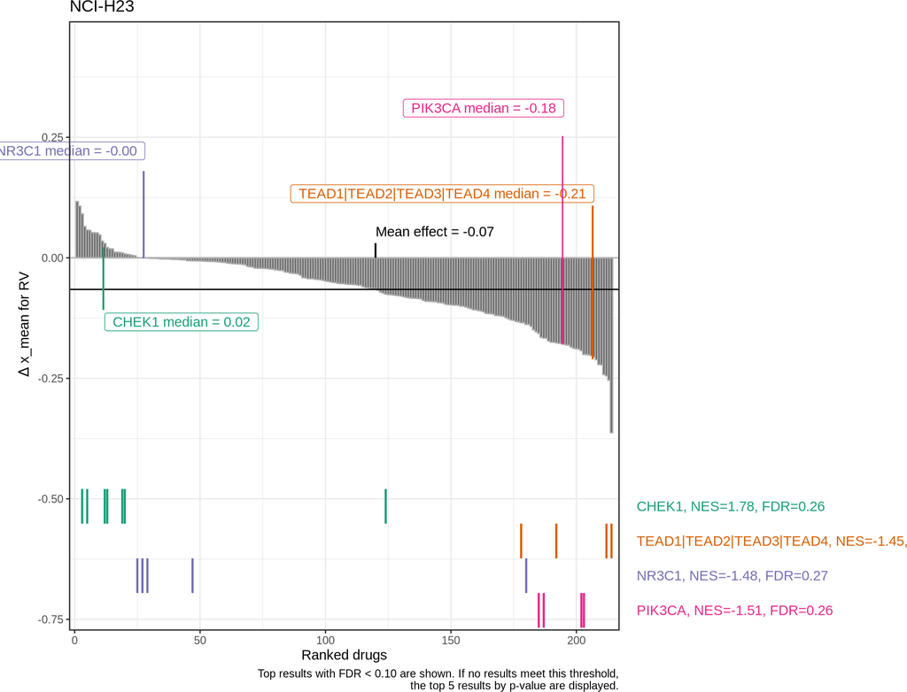

#### 6.1.1.2 x_AOC_range

🔍 Zoom In for Details

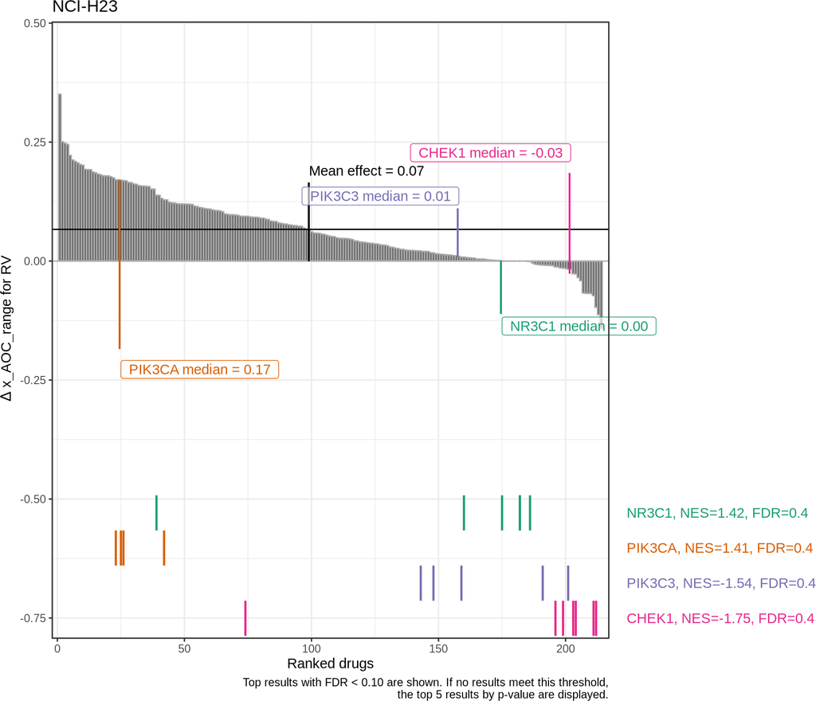

#### 6.1.1.3 xc50

🔍 Zoom In for Details

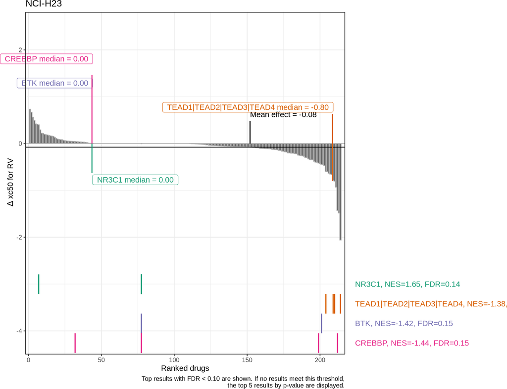

#### 6.1.1.4 ec50

🔍 Zoom In for Details

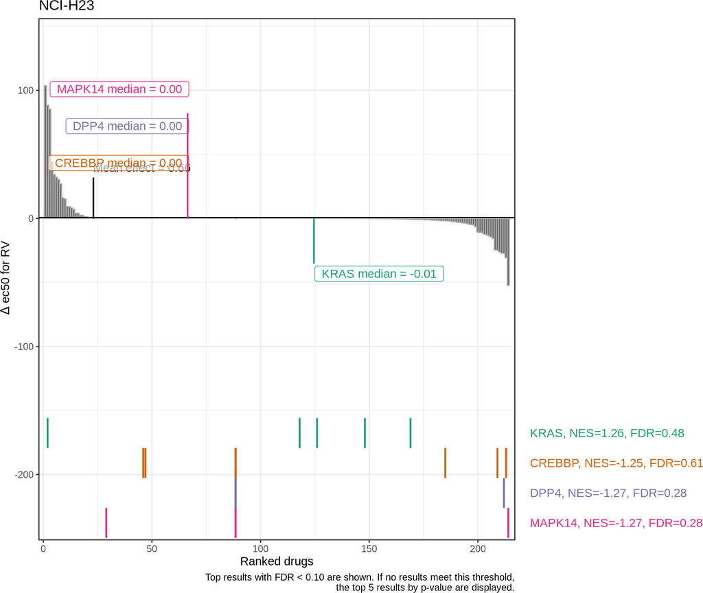

#### 6.1.1.5 x_max

🔍 Zoom In for Details

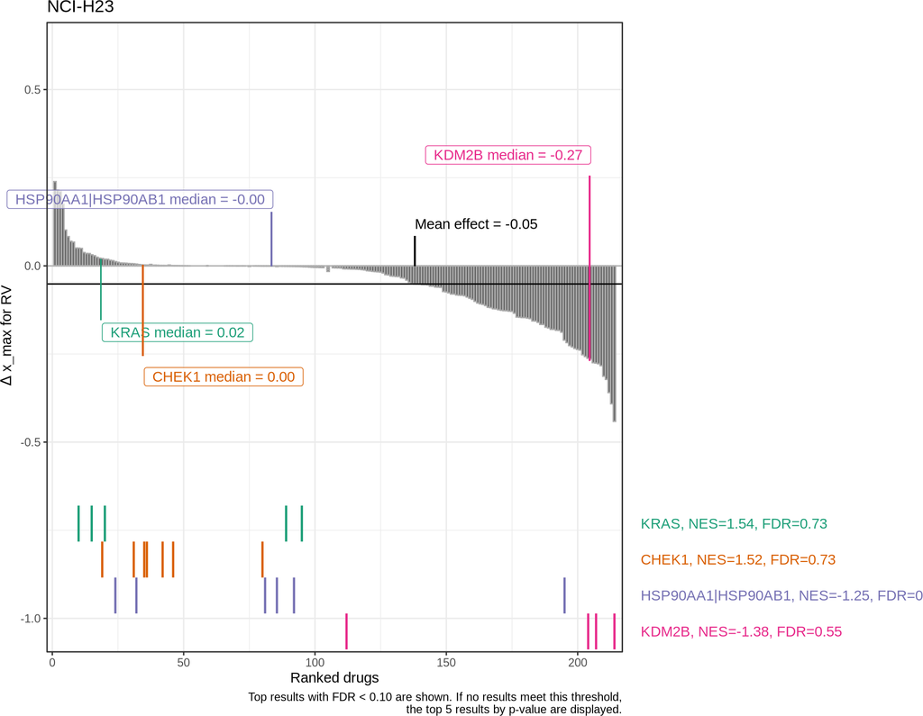

### 6.1.2 NCI-H358

#### 6.1.2.1 x_mean

🔍 Zoom In for Details

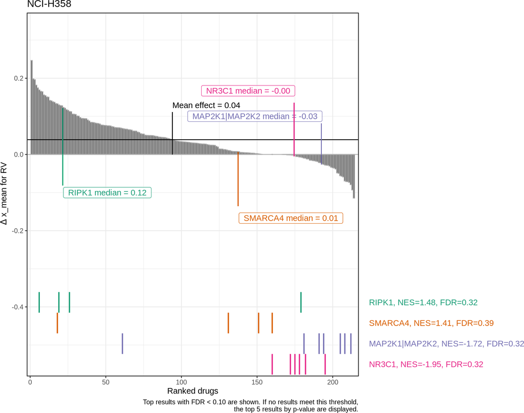

#### 6.1.2.2 x_AOC_range

🔍 Zoom In for Details

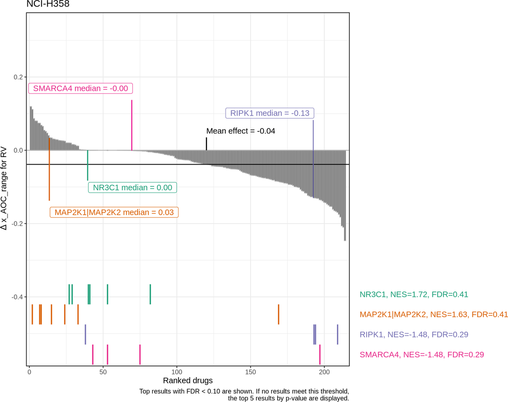

#### 6.1.2.3 xc50

🔍 Zoom In for Details

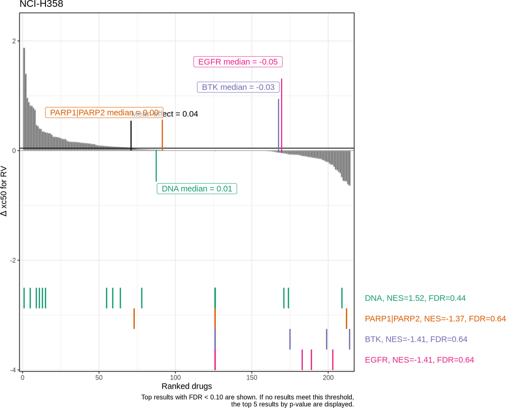

#### 6.1.2.4 ec50

🔍 Zoom In for Details

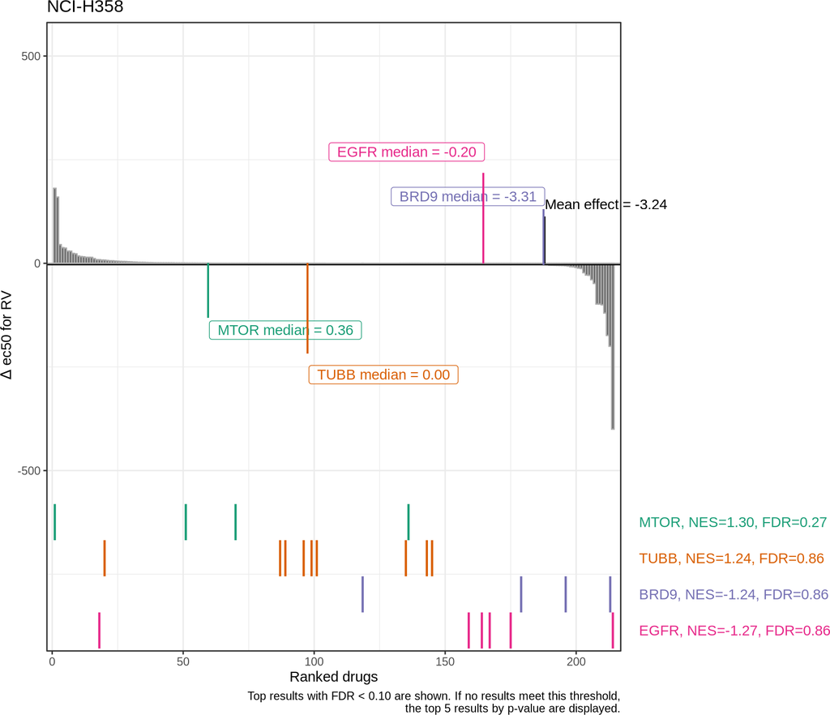

#### 6.1.2.5 x_max

🔍 Zoom In for Details

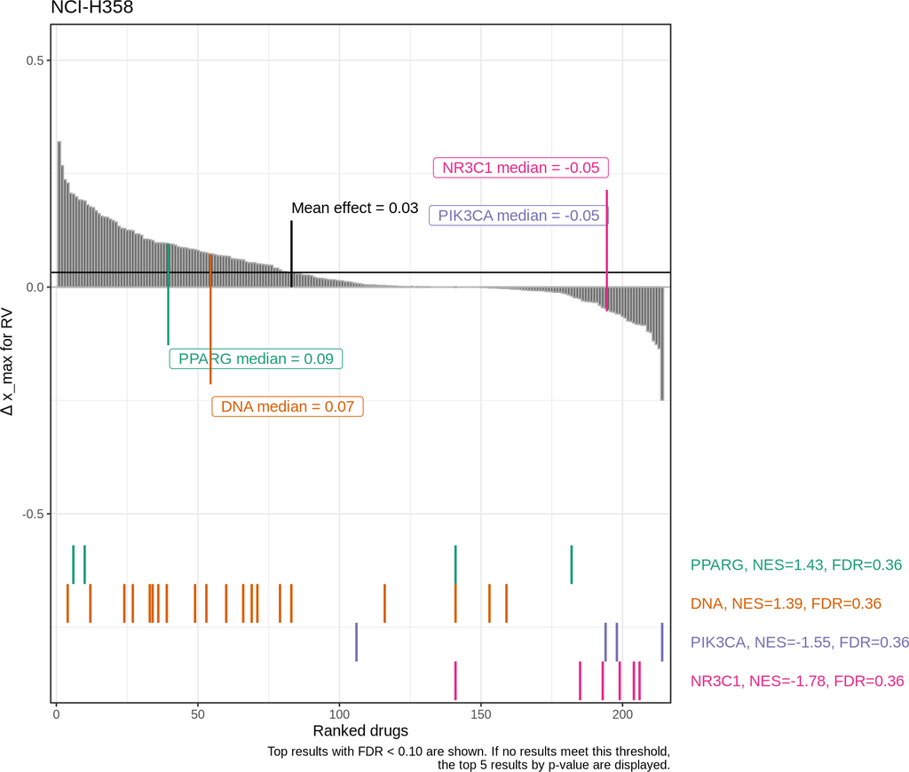

### 6.1.3 NCI-H23-R

#### 6.1.3.1 x_mean

🔍 Zoom In for Details

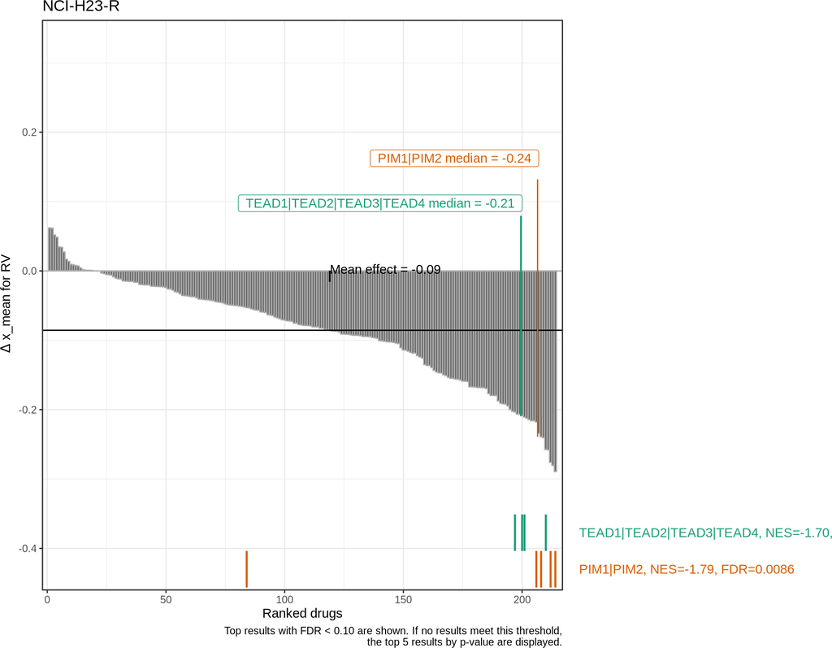

#### 6.1.3.2 x_AOC_range

🔍 Zoom In for Details

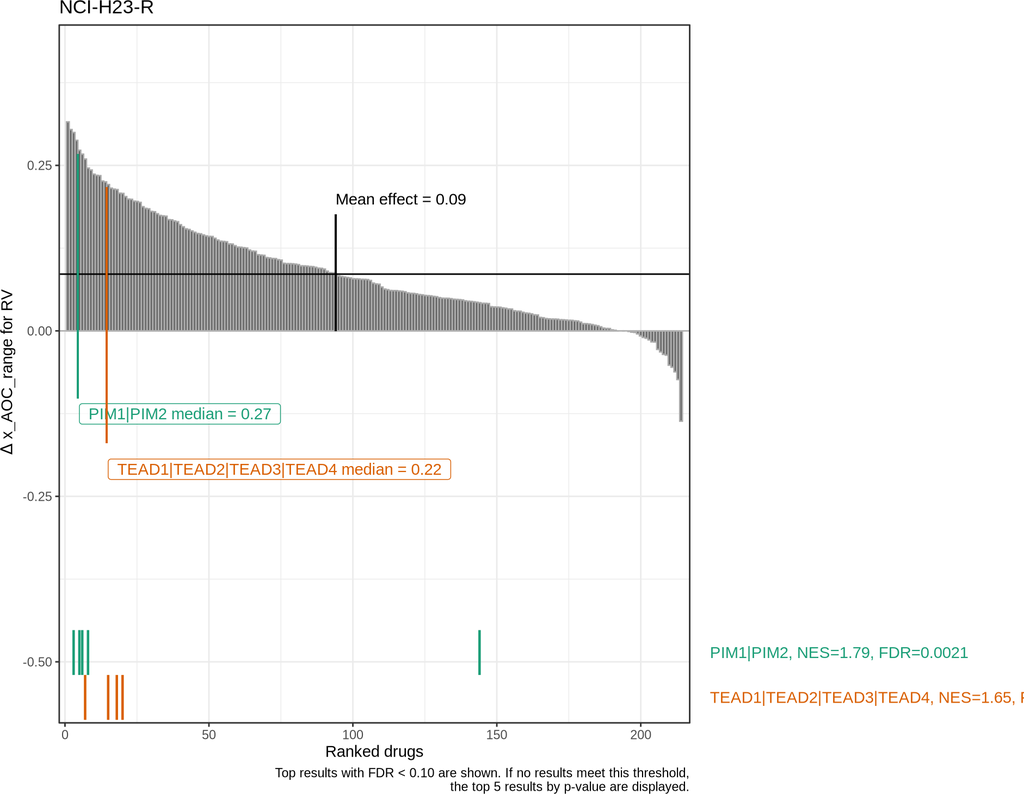

#### 6.1.3.3 xc50

🔍 Zoom In for Details

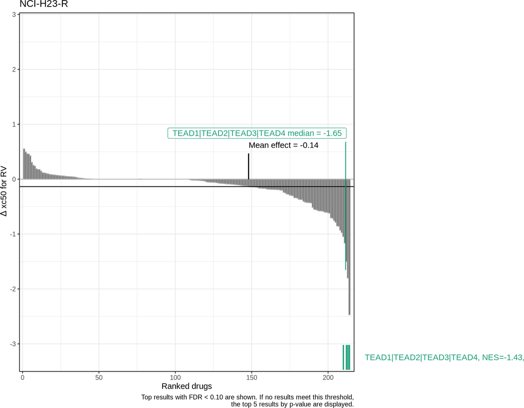

#### 6.1.3.4 ec50

🔍 Zoom In for Details

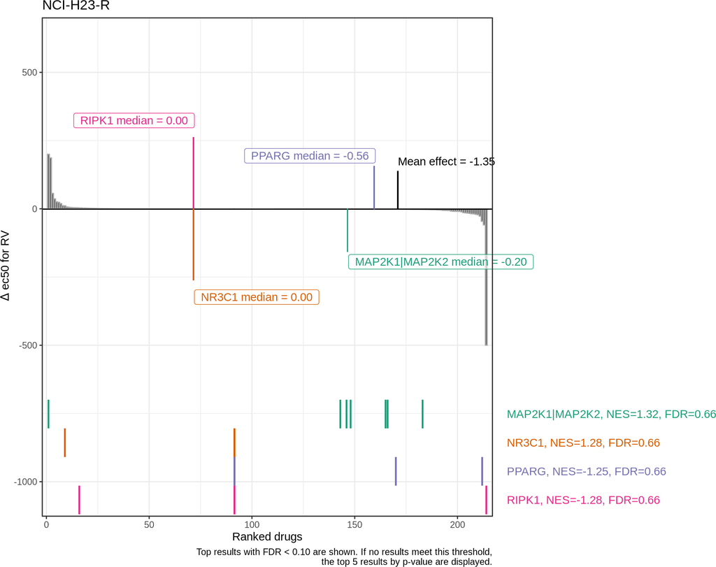

#### 6.1.3.5 x_max

🔍 Zoom In for Details

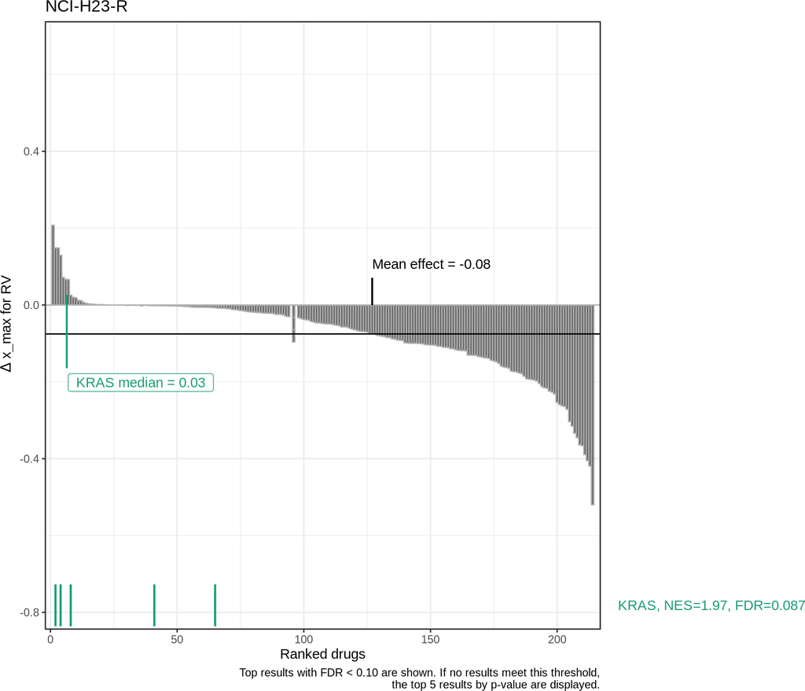

### 6.1.4 NCI-H358-R

#### 6.1.4.1 x_mean

🔍 Zoom In for Details

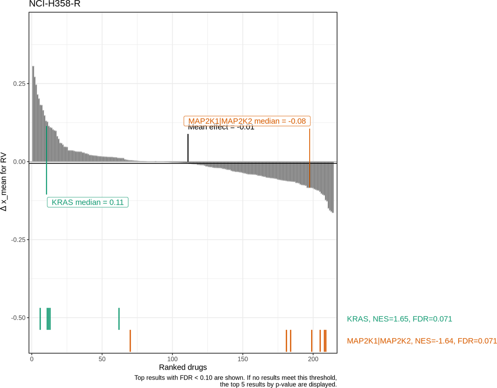

#### 6.1.4.2 x_AOC_range

🔍 Zoom In for Details

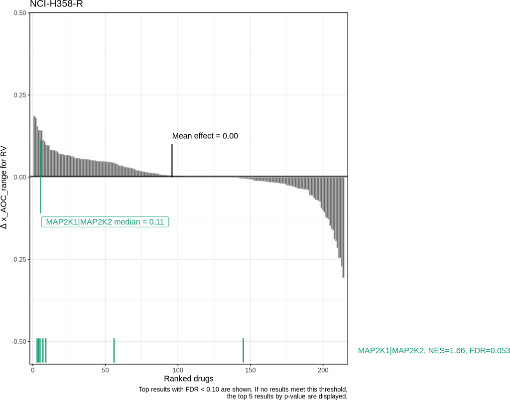

#### 6.1.4.3 xc50

🔍 Zoom In for Details

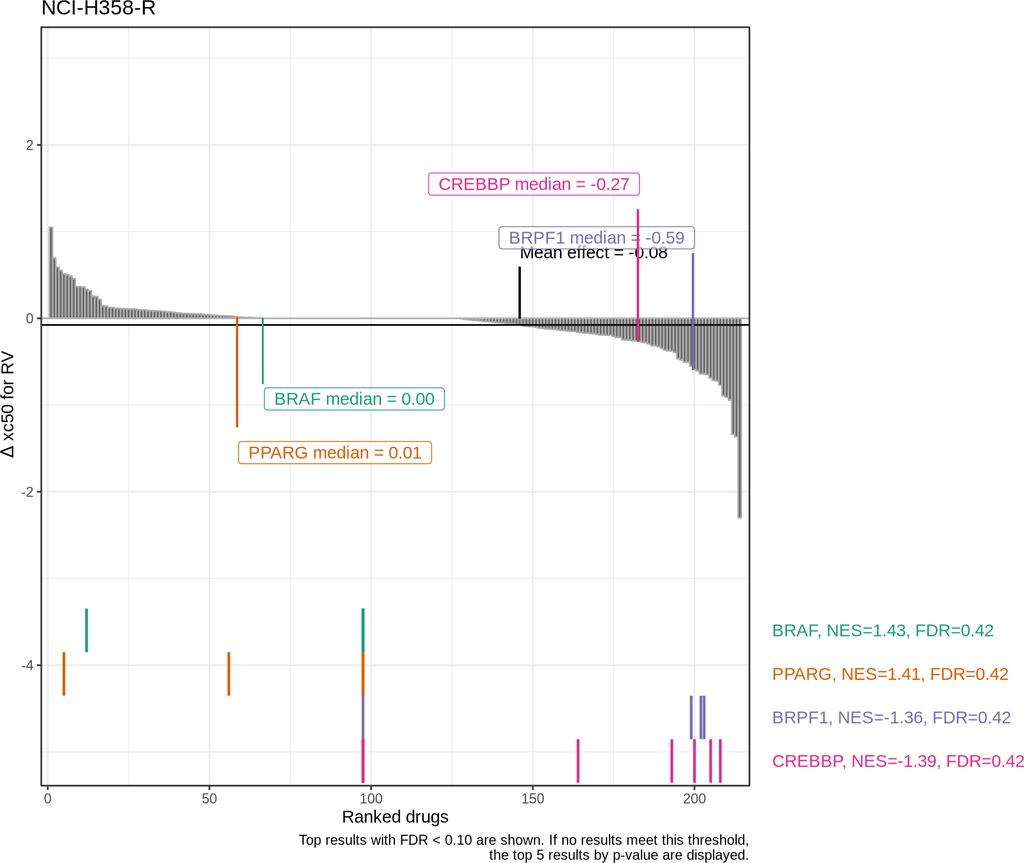

#### 6.1.4.4 ec50

🔍 Zoom In for Details

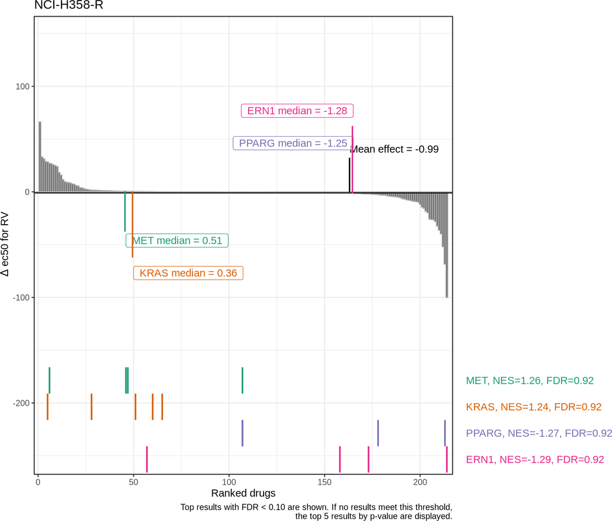

#### 6.1.4.5 x_max

🔍 Zoom In for Details

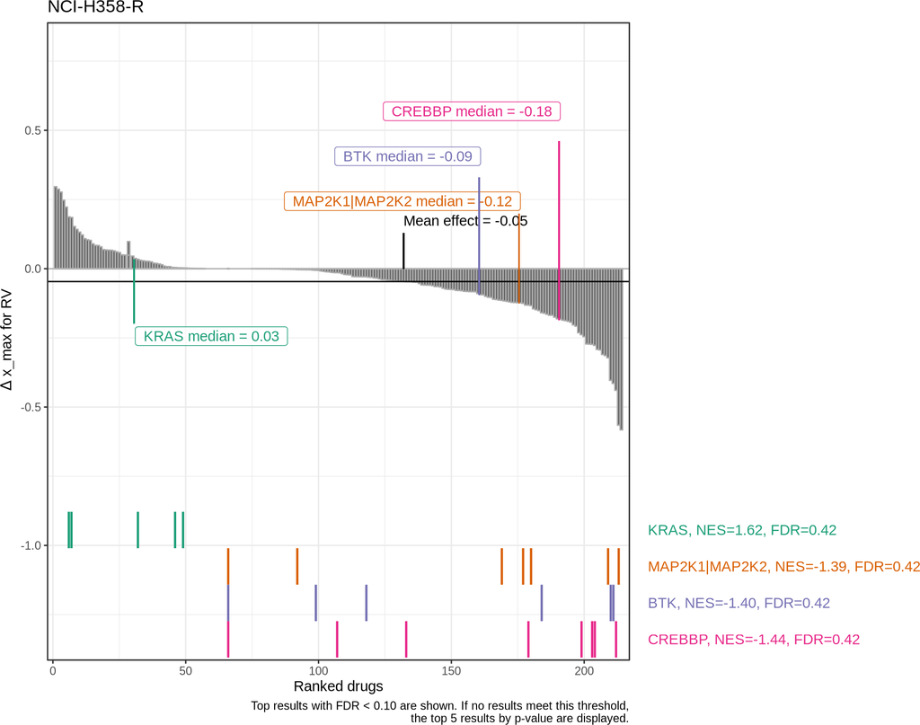

# 7 GSEA: Comparing Resistant and Parental Cell Lines

This second analysis compares each resistant cell line with its parental line, as in Fig. 4d of Hagenbeek et al. (2023): the mean viability of the resistant cells kept in the anchor drug (the combination arm, 900 nM) against the parental cells treated with the library drug alone. All drugs are ranked by this difference, and GSEA tests which drug classes (MOAs) the resistant cells depend on more (negative NES) or less (positive NES) than the parental cells. The pairs come from the `parental_identifier` of the cell line annotation.

*(The interpretation guide for the results table is the same as in the section above, but the NES now represents the difference between the resistant and the parental cells.)*

```r
analyzed_metrics <- "x_mean"
cell_line_name <- get_env_identifiers("cellline_name")

# a resistant line is one whose parental_identifier names another cell line of the screen
cell_lines <- unique(response_metrics_combo_capped[, c(cell_line_name, "parental_identifier"), with = FALSE])
resistant_pairs <- cell_lines[get(cell_line_name) != parental_identifier &
                                parental_identifier %in% get(cell_line_name)]
resistant_pairs
```

```
##    CellLineName parental_identifier
##          <char>              <char>
## 1:    NCI-H23-R             NCI-H23
## 2:   NCI-H358-R            NCI-H358
```

```r
cgs_analysis_RV <- do.call(c, lapply(seq_len(NROW(resistant_pairs)), function(i) {
  resistant <- resistant_pairs[[cell_line_name]][i]
  parental <- resistant_pairs$parental_identifier[i]
  # the resistant cells are compared at the anchor drug concentration they were screened with
  cotrt <- max(response_metrics_combo_capped[get(cell_line_name) == resistant, cotrt_value], na.rm = TRUE)
  analyze_cgs_conditions(response_metrics_combo_capped,
                         condition1 = list(cell_line = resistant, cotrt_value = cotrt),
                         condition2 = list(cell_line = parental, cotrt_value = 0),
                         metrics = analyzed_metrics,
                         normalization_type = "RV")
}))
```

## 7.1 Relative Viability

### 7.1.1 NCI-H23-R (co-treatment 0.899) vs. NCI-H23 (single agent)

💾 Download Table

#### 7.1.1.1 x_mean

|  | pathway | pval | padj | log2err | ES | NES | size | leadingEdge | median |
| --- | --- | --- | --- | --- | --- | --- | --- | --- | --- |
| 1 | MAP2K1\|MAP2K2 | 0.0007658800440381025 | 0.009956440572495333 | 0.3663530355510307 | 0.8047224141111488 | 2.238508554868258 | 7 | G10427, G10370, G10703, G10516, G10281 | 0.07062893105829826 |
| 2 | ESR1 | 0.09645301804604854 | 0.4702084629744867 | 0.03181792306608881 | 0.5072463768115942 | 1.411014946281649 | 7 | G10745, G10539, G10571, G10731, G10221, G10283, G10356 | -0.03566666666666674 |
| 3 | KRAS | 0.1092739881675352 | 0.4735206153926524 | 0.02693692800451113 | 0.5799540939618012 | 1.382826040647569 | 5 | G10623, G10564, G10162 | 0.05899272903172581 |
| 4 | BRAF\|RAF1\|ARAF | 0.1434161338783496 | 0.5593229221255633 | 0.02205177579466007 | 0.6113878099131326 | 1.316097832242179 | 4 | G10521, G10005, G10520 | 0.09477058579610931 |
| 5 | MDM2 | 0.1826587783567762 | 0.6025208318745185 | 0.02063221735080284 | 0.5221147424001036 | 1.244915536443156 | 5 | G10701 | -0.02067556219852063 |
| 6 | HDAC1\|HDAC2 | 0.2006127040352305 | 0.6025208318745185 | 0.02181453448564982 | 0.4386621783561661 | 1.220233240342919 | 7 | G10110, G10698, G10319, G10712 | 0.02997964678414688 |
| 7 | SMARCA4 | 0.2839325018341893 | 0.6920854732208364 | 0.0153397398931603 | 0.5238095238095238 | 1.127573313722875 | 4 | G10392, G10140, G10694, G10451 | -0.04260555555555562 |
| 8 | MAPK1\|MAPK3 | 0.320668890525495 | 0.7265222817326191 | 0.0161367744764771 | 0.4186344425776528 | 1.086694136772596 | 6 | G10622, G10113, G10584 | 0.02062199352037969 |
| 9 | BRAF | 0.6084966635223422 | 0.9573450803652347 | 0.009934384576817442 | 0.4095238095238095 | 0.8815573180015207 | 4 | G10239, G10389, G10213, G10717 | -0.010397282454089 |
| 10 | HMGCR | 0.6315903478750595 | 0.9573450803652347 | 0.0110433770465502 | 0.3317307692307693 | 0.8611089897202437 | 6 | G10257, G10577, G10674, G10018, G10432, G10034 | -0.07628356439324846 |

[output cut: 29 more lines]

### 7.1.2 NCI-H358-R (co-treatment 0.899) vs. NCI-H358 (single agent)

💾 Download Table

#### 7.1.2.1 x_mean

|  | pathway | pval | padj | log2err | ES | NES | size | leadingEdge | median |
| --- | --- | --- | --- | --- | --- | --- | --- | --- | --- |
| 1 | MAP2K1\|MAP2K2 | 0.01012206510138741 | 0.1315868463180363 | 0.05840339392230344 | 0.782608695652174 | 1.643073253569865 | 7 | G10703, G10332, G10516, G10427, G10370, G10212, G10281 | 0.1119270421164373 |
| 2 | CHEK1 | 0.01429095517609392 | 0.1393368129669157 | 0.04908434082438753 | 0.7681159420289855 | 1.612645971096349 | 7 | G10739, G10530, G10438, G10122, G10531, G10271, G10679 | 0.1763556838439536 |
| 3 | EGFR | 0.0260832769126608 | 0.1500224226418855 | 0.03647308593273869 | 0.767751185956731 | 1.53681798924128 | 6 | G10721, G10643, G10191, G10093 | 0.1037304389377736 |
| 4 | BRAF\|RAF1\|ARAF | 0.0269271014998256 | 0.1500224226418855 | 0.03643706840221018 | 0.8393426328273851 | 1.488747926853503 | 4 | G10520, G10521 | 0.143441183397243 |
| 5 | RIPK1 | 0.06456226020230206 | 0.2796387453978071 | 0.02326995072418579 | 0.7894037009965678 | 1.400170892487971 | 4 | G10040, G10414 | 0.07213519134962887 |
| 6 | KRAS | 0.07887246665066355 | 0.2796387453978071 | 0.02077756282913248 | 0.7360303171481994 | 1.395088124207521 | 5 | G10623, G10564, G10289, G10162 | 0.1309243751116607 |
| 7 | MDM2 | 0.09293234114056445 | 0.3016264530624206 | 0.01905881054696769 | 0.7233936781201414 | 1.371136359413039 | 5 | G10290, G10701 | 0.05948898294412475 |
| 8 | BRAF | 0.1187652598535054 | 0.3087896756191141 | 0.01687729442361804 | 0.7451062098160071 | 1.321600121052567 | 4 | G10717 | -0.007555555555555538 |
| 9 | KDM2B | 0.1849668643181026 | 0.4243357475532941 | 0.01324538216098597 | 0.7047031050506017 | 1.24993685017197 | 4 | G10447, G10209 | 0.04531069129298937 |
| 10 | ERN1 | 0.2115626089989536 | 0.4583856528310661 | 0.01227875729848222 | 0.6904761904761905 | 1.224702471802758 | 4 | G10369, G10412, G10284, G10579 | 0.09089847782863153 |

[output cut: 29 more lines]

# 8 Visualizing Resistant vs. Parental GSEA Results

**What to look for:**

- **Main Bar Plot (Waterfall):** The main plot at the top shows all drugs ranked by their differential metric value.
- **Colored Barcodes:** Below the main plot, each colored horizontal bar represents a statistically significant drug class (MOA). The vertical tick marks (‘barcode’) show the positions of the drugs from that class within the overall ranking.
- **Text Labels (Right Side):** The text on the right provides the statistics for each enriched MOA, including the **NES** (direction and magnitude) and the **FDR** (statistical significance).

```r
nested_list_RV <- lapply(names(cgs_analysis_RV), function(cl) {
  metric_results <- lapply(analyzed_metrics, function(m) {
    plot_cgs_ranking(results = cgs_analysis_RV, cl, m)
  })
  names(metric_results) <- analyzed_metrics
  return(metric_results)
})
names(nested_list_RV) <- names(cgs_analysis_RV)
```

## 8.1 Relative Viability

### 8.1.1 NCI-H23-R (co-treatment 0.899) vs. NCI-H23 (single agent)

#### 8.1.1.1 x_mean

🔍 Zoom In for Details

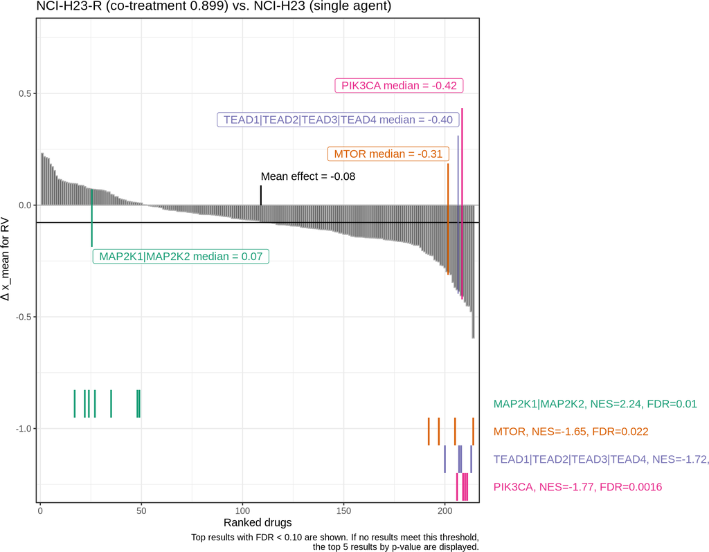

### 8.1.2 NCI-H358-R (co-treatment 0.899) vs. NCI-H358 (single agent)

#### 8.1.2.1 x_mean

🔍 Zoom In for Details

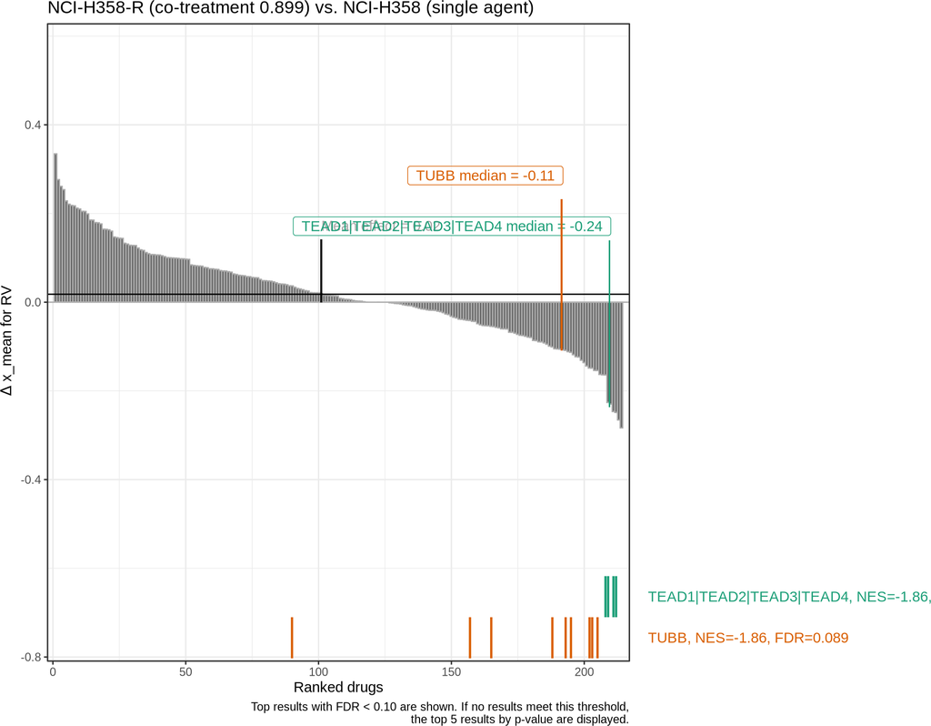

# 9 Conclusion

This report has performed a Gene Set Enrichment Analysis (GSEA) on the chemical genomics data to identify enriched drug classes based on their mechanism of action. The results highlight which drug MOAs are significantly sensitized or rescued by co-treatment, or show differential sensitivity between cell lines, providing valuable insights for further biological investigation.

### We Value Your Feedback!

Thank you for using gDR! We are always looking to improve, and your feedback is incredibly valuable to us.

[Share feedback or request features on GitHub](https://github.com/gdrplatform/gDRworkshops/issues)

# 10 gDR session info

```r
gdr_elapsed <- (proc.time() - gdr_start_time)[["elapsed"]]
message(sprintf("Report generated in %.1f seconds", gdr_elapsed))
gdr_sdt <- get_gDR_session_info()
generate_datatable(gdr_sdt)
```

|  | Package | Version |
| --- | --- | --- |
| 1 | gDR | 1.11.29 |
| 2 | gDRcomponents | 1.4.130 |
| 3 | gDRcore | 1.11.33 |
| 4 | gDRimport | 1.11.17 |
| 5 | gDRin | 0.2.103 |
| 6 | gDRinternal | 1.1.53 |
| 7 | gDRinternalData | 0.0.15 |
| 8 | gDRiPlots | 0.0.27 |
| 9 | gDRplots | 0.99.17 |
| 10 | gDRsearch | 1.3.42 |

[output cut: 5 more lines]

```r
cat(sprintf("**Report generation time: %.1f seconds**", gdr_elapsed))
```

```
## **Report generation time: 77.0 seconds**
```